# Digit tallying

Malcolm Ross

## 1. Two early Oceanic counting systems

Alongside their inherited decimal system (§14.1.2: Table 14.1) early Oceanic speakers in mainland New Guinea, New Britain, New Ireland, Bougainville, Vanuatu and New Caledonia apparently used a digit tally system, a formalised method of counting on one’s fingers, and in some communities on one’s toes too. The area for which numerals provide evidence of digit tallying is geographically discontinuous (Map 15.1). Linguistically it consists of WOc minus the western Solomons (Choiseul, New Georgia, Santa Isabel) along with SOc. For the sake of brevity, these areas are called the “digit tally areas” here. Just two languages, Seimat (Adm) and Gela (SES), that have evidence of digit tallying lie outside these areas.

The tasks of this chapter are, first, to examine the evidence for digit tallying and, second, to ask why its presence has brought about changes in numeral systems in the digit tally areas, but not in Oceanic languages elsewhere. An important question is why the digit tally area is geographically discontinuous. Why, for example, did digit tallying affect numeral systems in the digit tally areas, but in almost no Admiralty or SE Solomonic languages?

The presence of tallying alongside the inherited decimal system in the digit tally areas is unproblematic. Section 14.2.2 proposes that the decimal system was used to its fullest extent for ceremonial purposes. It also implies that counting was not used in everyday life to the degree that it is used in modern Western societies. People, for example, were less frequently counted than in Europe (§14.2.1.3). Measuring evidently used numbers much less than a westerner might expect (Chapter 16). When counting was used in everyday life, the fingers were used along with—in many communities—a small subset of inherited numerals.

Evidence for digit tallying today, or recently, is given in §15.2. Evidence for digit tallying in the past is found in many numeral systems in the digit tally areas and some outside them. Numeral systems with four quite widespread structures are examined in this chapter, and to this end a more formal terminology than the one used in chapter 14 is needed. This is the topic of §15.3, and §15.4 employs it to describe the four system structures. The forms of various numeral words reflect a digit-tallying past (§15.5). Section 15.6 shows the rather skewed distribution of the four system structures across Oceanic, and §15.7 investigates the origins of the three system structures that have a 5-base. Using evidence from the foregoing sections, §15.8 suggests answers to the questions above, and §15.9 summarises the chapter’s main arguments.

## 2. Digit-tallying practices

Digit tallying takes a number of forms around the world, and is more deeply embedded in some cultures than in others (Bender & Beller 2012). Observations of children show that finger-counting is not a necessary part of learning to count, and is thus not essential to developing a numeral system (Crollen, Seron & Noël 2011). It is not embedded in Ponam (Adm) culture, for example, where Carrier (1981:468) notes that people generally do not count on their fingers, except when, for example, an adult is counting something they see or visualise in memory.

The general Oceanic pattern of tallying by counting off the fingers of one hand, then the other, and then perhaps the toes of each foot, to arrive at ‘one person’, i.e. 20, has also been documented from the Arctic to Mesoamerica (Closs 1986), in west Africa, and in Khoekhoe languages of southern Africa (Bender & Beller 2012).

Accounts of tallying among groups of Oceanic speakers indicate that each speech community had its own procedure, but almost all entailed holding hands open toward the speaker’s face, then progressively folding the fingers down until one had two fists, i.e. 10. Some communities also employed the toes, and some repeated the process with the fingers as a proxy for toes until they reached ‘one person’. Both possibilities existed for Kairiru speakers (NNG; Wivell 1981). Fingers and toes were used by Mengen (NNG; Panoff 1970) and by Drehu speakers (NCal; Ray 1926:134). Groups who used fingers only include the Lihir and Sursurunga of New Ireland (MM; Neuhaus 2015:131; Hutchisson 1977) and the Banks and Ambae islanders of northern Vanuatu (Codrington 1891:353). In other accounts this information is omitted, perhaps because people only used their hands.

Some accounts specify whether tallying began with the left hand or the right. Wivell tells us that the Kairiru started with the left hand, then moved to the right, then to the right foot before the left. Speakers of Mengen, Tangga of New Ireland (MM; Maurer 1966:75) and Gela (SES; Codrington 1891:353) started with the right hand, the Banoni of Bougainville (MM; Lincoln 2010:230) with the left.

Speakers of Nalik (MM; Volker 1998:118), Tangga, Banoni and Gela started tallying from the little finger of each hand, speakers of Lihir, Sursurunga and Banks languages from the thumb. Speakers of Drehu began each hand with the thumb, and each foot with the big toe.

Codrington reports that Ambae islanders use only one hand to count. They start with the thumb, and when they have reached 5 and all fingers are down, they straighten all fingers again, this time counting from the forefinger to the little finger and reserving the thumb for 10.

If Maurer’s (1966:74) account is correct, Tangga speakers counted both hands and said, “*tika*” (‘1’), then counted them again and said, “*tike saŋful*” (‘one ten’), but meaning that they had counted 20. They then repeated the whole process and ended with “*iu e saŋful*” (‘2 tens’), meaning 40. Maurer offers no explanation for this, but I infer that this was public counting and involved counting in pairs (cf §14.6.3). Maurer (1966:75) goes on to say that “if the objects were not present”, i.e. if one was counting something privately in one’s head, then one started with the little finger of the open hand and counted both hands serially to ten, then repeated the process, if necessary plucking leaflets from a fern frond to keep count of the tens.

Panoff (1970:363–364) also describes two modes of tallying among the Mengen. For numbers below 20, they tallied in pairs:

> When single units are involved, the Maenge begin counting on the right hand, which is held up open. First, the index finger [forefinger] of the right hand touches the thumb of the same hand while one says *lua* (‘two’). The middle and fourth [ring] fingers of the same hand are then clustered together and bent downward while one again says *lua*. Finally, the little finger of the same hand is bent while one says *ne lima* (the ordinal for ‘five’). Once this has been done, one passes on to the left hand, using its fingers as tallies in the same way as those of the right hand and again calling the numerals *lua*, *lua*, *ne lima*. At this point one closes the fists, both hands being held up together, and says *tangulelu* (‘10’). If the number of objects to be counted exceeds ten, one proceeds to the toes of the right foot, which are touched with the right forefinger in the same two-two-one succession, the same numerals as before being uttered afresh. To reach twenty, one resumes the operation on the left foot with the left forefinger used as a pointer. The numeral *giaukaena* (‘20’) [‘a person’s feet’—MR] is then called, and one stoops and places both closed fists on the toes to show the completion of the vigesimal series.

The second method, apparently used when a large number of objects was counted in twenties, was straightforward tallying.

It is clear, then, that Oceanic speakers in the digit tally areas do or did use tallying as a means of counting. Whether speakers outside these areas also did so is largely a matter of conjecture. Carrier (1981) writes that it was not common practice among Ponam (Adm) speakers. As the examples in this section were noted in the course of reading others’ research, and no comparative research on digit tallying in the Pacific has been done, it may be sheer chance that, with the exceptions of Seimat and Gela, examples outside the digit tally areas have not been found.

Evidence of earlier digit tallying comes from numeral systems themselves, both from number words derived from ‘hand’, ‘foot’, ‘thumb’ or person, and from systems that diverge significantly in structure from the decimal systems described in Chapter 14.

Note, though, that among the languages mentioned in this section, Sursurunga, Tangga, Gela and NE Ambae have decimal systems. Thus it need not be supposed that communities with decimal counting do not also use tallying.

## 3. Terminology

Numerals are unlike many lexical items[^1] in that in most languages their meanings form a highly ordered semantic domain. The forms that express those meanings are composed of a limited number of single-morpheme words—**simple numerals**—which also serve, sometimes with modification, as components for the specialised part of the grammar that constructs numerals with more than one morpheme. These are **complex numerals**. For example, *two hundred and one* is a complex numeral made up of the simple numerals *one*, *two* and *hundred* and the morpheme *and* in accordance with the grammar (Booij 2010:195–204). The grammar allows speakers to generate large numbers of numerals, with the need only to store simple numerals in memory, probably along with some frequently used complex numerals (Greenberg 2000:74–75; Moravcsik 2013:47).

The way a numeral system’s semantic domain is structured varies from language to language. In a majority of languages worldwide the structure is base-10 (decimal), but structures with base-5 and base-20, replicating the hands and feet used in digit-tallying, are fairly common (§15.6).

**Table 15.1** Cyclicity in Mussau numerals (Brownie & Brownie 2007)

| tens: | 0 | 10 | 20 | 30 | 40 |
| --- | --- | --- | --- | --- | --- |
| 0 | — | *sa-ŋaulu* | *lue-ŋaulu* | *tolu-ŋaulu* | *ati-ŋaulu* |
| 1 | *sesa* | *sa-ŋaulu sesa* | *lue-ŋaulu sesa* | *tolu-ŋaulu sesa* | *ati-ŋaulu sesa* |
| 2 | *lua* | *sa-ŋaulu lua* | *lue-ŋaulu lua* | *tolu-ŋaulu lua* | *ati-ŋaulu lua* |
| 3 | *tolu* | *sa-ŋaulu tolu* | *lue-ŋaulu tolu* | *tolu-ŋaulu tolu* | *ati-ŋaulu tolu* |
| 4 | *ata* | *sa-ŋaulu ata* | *lue-ŋaulu ata* | *tolu-ŋaulu ata* | *ati-ŋaulu ata* |
| 5 | *lima* | *sa-ŋaulu lima* | *lue-ŋaulu lima* | *tolu-ŋaulu lima* | *ati-ŋaulu lima* |
| 6 | *nomo* | *sa-ŋaulu nomo* | *lue-ŋaulu nomo* | *tolu-ŋaulu nomo* | *ati-ŋaulu nomo* |
| 7 | *itu* | *sa-ŋaulu itu* | *lue-ŋaulu itu* | *tolu-ŋaulu itu* | *ati-ŋaulu itu* |
| 8 | *oalu* | *sa-ŋaulu oalu* | *lue-ŋaulu oalu* | *tolu-ŋaulu oalu* | *ati-ŋaulu oalu* |
| 9 | *sio* | *sa-ŋaulu sio* | *lue-ŋaulu sio* | *tolu-ŋaulu sio* | *ati-ŋaulu sio* |

Most numeral systems have a cyclic structure (Salzmann 1950:81). The cyclicity of Mussau’s decimal numeral system in Table 15.1 is self-evident. The **lowest numerals** in the system (in column 0) are simple ones counting from 1 to 9 and form the first cycle. In columns 10 to 40 the element in row 0—call it *n*—e.g. *lue-ŋaulu* ‘20’, introduces a **round** of this cycle. The cells below it contain a complex numeral, e.g. *lue-ŋaulu tolu* ‘23’, consisting of *n* preceded by an element that replicates 1–9 from the first cycle, each column forming a fresh round (10–19, 20–29 etc). The first morpheme of each *n*, namely *sa-*, *lue-*, *tolu-*, *ati-*, is a version of one of 1 to 4 and together they form a superordinate cycle. If this cycle were shown in full, its rightmost column would be headed by *sio-ŋaulu* ‘90’, and the table would end with 99, after which a second round of the superordinate cycle would begin with *ai* ‘100’.

Thus each column is a round of a 10-cycle, and the superordinate cycle represented by the first row (*sa-ŋaulu* etc) is a 100-cycle. A cycle defines a **base**. The base of the first cycle, 10 (*-ŋaulu*), initiates the second and further rounds of the 10-cycle (the columns of Table 15.1). Similarly the base of the next cycle, 100 (*ai*), initiates the second and further rounds of the 100-cycle (*rua ai* ‘200’ etc). Mussau is thus a base-10 (or decimal) system, or, more exactly, a base-10-100 system.

Commonly, complex numerals in non-initial rounds of a cycle are formed by adding lowest numerals to the base numeral (e.g. *sa-ŋaulu* *sesa* ‘11’, *sa-ŋaulu* *lua* ‘12’, etc) or by multiplying the base numeral by a numeral smaller than the base (e.g. *sa*-*ŋaulu* ‘10’, *lue*-*ŋaulu* ‘20’, etc). Thus Mussau has a **canonic** system, canonic in that it follows regularly a small set of rules for generating complex numerals (cf Hammarström 2008:290).

## 4. Cyclicity in numeral systems of the digit tally areas

Decimal systems also occur within the digit tally areas, but three other types of system structure are common: base-5-10, base-5-20 and base-5-10-20. I will refer to them collectively as ‘base-5+’ systems. The following subsections describe an example of each of these systems.

**Table 15.2** a) Cyclicity in Daakaka numerals (von Prince 2012:224–225): base-5

| fives: | 0 |  | 5 |  |
| --- | --- | --- | --- | --- |
| 0 | — | — | *lim* | ‘5’ |
| 1 | *sʷa* | ‘1’ | *milip-sʸes* | ‘6’ |
| 2 | *lo* | ‘2’ | *miliv-yo* | ‘7’ |
| 3 | *sī* | ‘3’ | *milip-sī* | ‘8’ |
| 4 | *vʸer* | ‘4’ | *me-per* | ‘9’ |

**Table 15.2** b) Cyclicity in Daakaka numerals (von Prince 2012:224–225): base-10

| tens: | 10 |  | 20 |  | 30 |  |
| --- | --- | --- | --- | --- | --- | --- |
| 0 | *suŋavi* | ‘10’ | *uŋ lo* | ‘20’ | *uŋ sī* | ‘30’ |
| 1 | *suŋavi a sʷa* | ‘11’ | *uŋ lo a sʷa* | ‘21’ | *uŋ sī a sʷa* | ‘31’ |
| 2 | *suŋavi a lo* | ‘12’ | *uŋ lo a lo* | ‘22’ | *uŋ sī a lo* | ‘32’ |
| 3 | *suŋavi a sī* | ‘13’ | *uŋ lo a sī* | ‘23’ | *uŋ sī a sī* | ‘33’ |
| 4 | *suŋavi a vyɛr* | ‘14’ | *uŋ lo a vyɛr* | ‘24’ | *uŋ sī a vyɛr* | ‘34’ |
| 5 | *suŋavi a lim* | ‘15’ | *uŋ lo a lim* | ‘25’ | *uŋ sī a lim* | ‘35’ |
| 6 | *suŋavi a milip-sʸes* | ‘16’ | *uŋ lo a milip-sʸes* | ‘26’ | *uŋ sī a milip-sʸes* | ‘36’ |
| 7 | *suŋavi a miliv-yɔ* | ‘17’ | *uŋ lo a miliv-yɔ* | ‘27’ | *uŋ sī a miliv-yɔ* | ‘37’ |
| 8 | *suŋavi a milip-sī* | ‘18’ | *uŋ lo a milip-sī* | ‘28’ | *uŋ sī a milip-sī* | ‘38’ |
| 9 | *suŋavi a mɛ-pɛr* | ‘19’ | *uŋ lo a mɛ-pɛr* | ‘29’ | *uŋ sī a mɛ-pɛr* | ‘39’ |

### 4.1. Base-5-10

The corresponding table for the NCV language Daakaka of Ambrym, Table 15.2, falls into two parts because its numeral system has two bases, the second interrupting the cyclicity of the first.

Daakaka starts with a 5 base, i.e. the lowest numerals stop at 5, as shown in the first part of Table 15.2. As the base-5 matrix in Table 15.2 shows, this part of the system lasts just two rounds. In Mussau the next higher base is 100, i.e. base×base (10×10). One might expect the next higher base in Daakaka to be base×base (5×5=25), but it isn’t. The base *suŋavi* ‘10’ intervenes, and from here on the system is decimal, with decades from 20 upward employing the much abbreviated *uŋ* in place of *suŋavi*, as shown in the base-10 matrix of Table 15.2.

Unlike Mussau, Daakaka has no further bases. 100 is simply *uŋ suŋavi* (10×10). Within each base-10 round are two subordinate base-5 rounds.

The numerals in the second base-5 round, 6 to 9, are formed additively, albeit with some morphophonemic changes. Such numerals began life as 5+1, 5+2 etc, with a ligature morpheme that functions like a plus sign. In many NCV languages the ligature reflects the POc neutral caused-motion verb *lapi ‘take, get, give’ (vol.5:426).[^2] The second syllable of the Daakaka ligature *milip-* reflects *lapi, while various origins of initial *mi-* can be posited (Lynch 2009:402).[^3] It is common for the ligature alone to function as the expression of 5+ in this context. Daakaka thus has a base-5-10 system, common throughout the digit tally areas (see Map 15.1). Where they reflect POc numerals such systems are treated as decimal in Chapter 14, as they differ from a base-10 system only in their treatment of 6–9.

Lynch’s (2009) “imperfect decimal” category of Oceanic numeral systems lumps together the additive 6–9 sequences in Daakaka, Mangap and Tuam with subtractive sequences like 7-9 in Ponam *aha-talo-f* [minus-3-CLF] ‘7’, *aha-luo-f* [minus-2-CLF] ‘8’, *aha-se* [minus-1-CLF] ‘9’ (§14.4.3.5).[^4] However, the subtractive sequence is not cyclic, so in this respect Ponam 10 does not define a base. The numeral ‘10’ is a base in Ponam, but because there is a base-10 cycle, not because it is a minuend.[^5]

### 4.2. Base-5-20

The Mangap (NNG) system, shown in Table 15.3, is similar to Daakaka insofar as it has two bases, but differs from it in several ways, the most salient of which is that the second base is 20, not 10, i.e. it is a base-5-20 system Hence there are four base-5 rounds before *tomō-ta* [20×1] ‘twenty’ interrupts base-5 cyclicity. After this interruption, numeration continues quite consistently, with base-5 rounds occurring within each superordinate base-20 round.

There is an oddity in the base-5 matrix. Instead of counting across row 0 *lama-ta* ‘one five’, *lāmu-ru* ‘two fives’, †*lāmu-tel* ‘three fives’, the expected *-tel* ‘3’ is replaced by *-ro-ma-ta* ‘2 plus 1’. Probably *lamo-ro-ma-ta* [hand-2-and 1] ‘15’ abbreviates a phrase meaning ‘two hands and one foot’, harking back to digit-tallying. Viewed from the perspective of numeral system structure, however, *lamo-ro-ma-ta* breaks a rule that would generate †*lāmu-tel*.

Base-5-20 systems are found scattered across parts of the digit tally areas (see Map 15.1). The Mangap system is not quite transparent because the language has undergone various vowel changes, mainly vowel harmonisations. The lowest base, *lama-* ‘5’, reflects POc *lima ‘five’. The second base, *tomō-ta* ‘one twenty’, is apparently a haplologic[^6] reduction of *tomōto-ta* and means ‘one man’, again suggesting a digit-tally system that counts two hands, one foot and four toes (*lamo-ro ma-ta mi paŋ*) for 19, then counts ‘one person’ or ‘one man’ for ‘20’.

It is a little difficult to believe that numerals the length of those in the bottom four lines of the base-20 matrix were used with any regularity in traditional societies, but grammar after grammar describes such systems, and they are not the inventions of the grammar writers. If one thinks of them as describing a tally, then, for example, *tomtō-ru lamo-ro-ma-ta mi ru* does not say, ‘57’, but ‘2 people (plus) 2 hands and (a foot) plus 2 (toes)’.

**Table 15.3** a) Cyclicity in Mangap numerals (Bugenhagen 1995:147–148): base-5

| fives: | 0 | 5 |  | 10 |  | 15 |  |
| --- | --- | --- | --- | --- | --- | --- | --- |
| 0 | — | *lama-ta* | ‘5’ | *lāmu-ru* | ‘10’ | *lamo-ro-ma-ta* | ‘15’ |
| 1 | _ta | *lama-ta mi ta* | ‘6’ | *lāmu-ru mi ta* | ‘11’ | *lamo-ro-ma-ta mi ta* | ‘16’ |
| 2 | _ru | *lama-ta mi ru* | ‘7’ | *lāmu-ru mi ru* | ‘12’ | *lamo-ro-ma-ta mi ru* | ‘17’ |
| 3 | _tel | *lama-ta mi tel* | ‘8’ | *lāmu-ru mi tel* | ‘13’ | *lamo-ro-ma-ta mi tel* | ‘18’ |
| 4 | _paŋ | *lama-ta mi paŋ* | ‘9’ | *lāmu-ru mi paŋ* | ‘14’ | *lamo-ro ma-ta mi paŋ* | ‘19’ |

**Table 15.3** b) Cyclicity in Mangap numerals (Bugenhagen 1995:147–148): base-20

| 20s: | 20 |  | 40 |  |
| --- | --- | --- | --- | --- |
| 0 | *tomō-ta* | ‘20’ | *tomtō-ru* | ‘40’ |
| 1 | *tomō-ta mi ta* | ‘21’ | *tomtō-ru mi ta* | ‘41’ |
| 2 | *tomō-ta mi ru* | ‘22’ | *tomtō-ru mi ru* | ‘42’ |
| 3 | *tomō-ta mi tel* | ‘23’ | *tomtō-ru mi tel* | ‘43’ |
| 4 | *tomō-ta mi paŋ* | ‘24’ | *tomtō-ru mi paŋ* | ‘44’ |
| 0 | *tomō-ta lama-ta* | ‘25’ | *tomtō-ru lama-ta* | ‘45’ |
| 1 | *tomō-ta lama-ta mi ta* | ‘26’ | *tomtō-ru lama-ta mi ta* | ‘46’ |
| 2 | *tomō-ta lama-ta mi ru* | ‘27’ | *tomtō-ru lama-ta mi ru* | ‘47’ |
| 3 | *tomō-ta lama-ta mi tel* | ‘28’ | *tomtō-ru lama-ta mi tel* | ‘48’ |
| 4 | *tomō-ta lama-ta mi paŋ* | ‘29’ | *tomtō-ru lama-ta mi paŋ* | ‘49’ |
| 0 | *tomō-ta lāmu-ru* | ‘30’ | *tomtō-ru lāmu-ru* | ‘50’ |
| 1 | *tomō-ta lāmu-ru mi ta* | ‘31’ | *tomtō-ru lāmu-ru mi ta* | ‘51’ |
| 2 | *tomō-ta lāmu-ru mi ru* | ‘32’ | *tomtō-ru lāmu-ru mi ru* | ‘52’ |
| 3 | *tomō-ta lāmu-ru mi tel* | ‘33’ | *tomtō-ru lāmu-ru mi tel* | ‘53’ |
| 4 | *tomō-ta lāmu-ru mi paŋ* | ‘34’ | *tomtō-ru lāmu-ru mi paŋ* | ‘54’ |
| 0 | *tomō-ta lamo-ro-ma-ta* | ‘35’ | *tomtō-ru lamo-ro-ma-ta* | ‘55’ |
| 1 | *tomō-ta lamo-ro-ma-ta mi ta* | ‘36’ | *tomtō-ru lamo-ro-ma-ta mi ta* | ‘56’ |
| 2 | *tomō-ta lamo-ro-ma-ta mi ru* | ‘37’ | *tomtō-ru lamo-ro-ma-ta mi ru* | ‘57’ |
| 3 | *tomō-ta lamo-ro-ma-ta mi tel* | ‘38’ | *tomtō-ru lamo-ro-ma-ta mi tel* | ‘58’ |
| 4 | *tomō-ta lamo-ro ma-ta mi paŋ* | ‘39’ | *tomtō-ru lamo-ro ma-ta mi paŋ* | ‘59’ |

### 4.3. Base-5-10-20

Another NNG language, Tuam, has a base-5-10-20 system, as Table 15.4 shows. Whereas the base-5 matrix in Mangap (Table 15.3) breaks off at 19, the base-5 matrix in Tuam (Table 15.4) breaks off at 9, as the next base, 10, intervenes, as in Daakaka. Notice that the form for ‘10’, *saŋavul*, reflects POc *saŋapuluq (§14.4.5.1). However, the 20 base, Tuam *tamōt-*, resembles Mangap *tomō-*, both in meaning ‘person’ and in hinting at an earlier digit tally system.

**Table 15.4** a) Cyclicity in Tuam numerals (Bugenhagen 2011): base-5

| fives: | 0 |  | 5 |  |
| --- | --- | --- | --- | --- |
| 0 | — | — | *līm* | ‘5’ |
| 1 | *ēz* | ‘1’ | *līm ve ēz* | ‘6’ |
| 2 | *ru* | ‘2’ | *līm ve ru* | ‘7’ |
| 3 | *tol* | ‘3’ | *līm ve tol* | ‘8’ |
| 4 | *pāŋ* | ‘4’ | *līm ve pāŋ* | ‘9’ |

**Table 15.4** b) Cyclicity in Tuam numerals (Bugenhagen 2011): base-10

| tens: | 10 |  |
| --- | --- | --- |
| 0 | *saŋavul* | ‘10’ |
| 1 | *saŋavul ve ēz* | ‘11’ |
| 2 | *saŋavul ve ru* | ‘12’ |
| 3 | *saŋavul ve tol* | ‘13’ |
| 4 | *saŋavul ve pāŋ* | ‘14’ |
| 0 | *saŋavul ve līm* | ‘15’ |
| 1 | *saŋavul līm ve ēz* | ‘16’ |
| 2 | *saŋavul līm ve ru* | ‘17’ |
| 3 | *saŋavul līm ve tol* | ‘18’ |
| 4 | *saŋavul līm ve pāŋ* | ‘19’ |

**Table 15.4** c) Cyclicity in Tuam numerals (Bugenhagen 2011): base-20

| 20s: | 20 |  | 40 |  |
| --- | --- | --- | --- | --- |
| 0 | *tamōt-ē* | ‘20’ | *tamōt ru* | ‘40’ |
| 1 | *tamōt-ē ve ēz* | ‘21’ | *tamōt ru ve ēz* | ‘41’ |
| 2 | *tamōt-ē ve ru* | ‘22’ | *tamōt ru ve ru* | ‘42’ |
| 3 | *tamōt-ē ve tol* | ‘23’ | *tamōt ru ve tol* | ‘43’ |
| 4 | *tamōt-ē ve pāŋ* | ‘24’ | *tamōt ru ve pāŋ* | ‘44’ |
| 0 | *tamōt-ē ve līm* | ‘25’ | *tamōt ru ve līm* | ‘45’ |
| 1 | *tamōt-ē līm ve ēz* | ‘26’ | *tamōt ru līm ve ēz* | ‘46’ |
| 2 | *tamōt-ē līm ve ru* | ‘27’ | *tamōt ru līm ve ru* | ‘47’ |
| 3 | *tamōt-ē līm ve tol* | ‘28’ | *tamōt ru līm ve tol* | ‘48’ |
| 4 | *tamōt-ē līm ve pāŋ* | ‘29’ | *tamōt ru līm ve pāŋ* | ‘49’ |
| 0 | *tamōt-ē ve saŋavul* | ‘30’ | *tamōt ru ve saŋavul* | ‘50’ |
| 1 | *tamōt-ē ve saŋavul ve ēz* | ‘31’ | *tamōt ru ve saŋavul ve ēz* | ‘51’ |
| 2 | *tamōt-ē ve saŋavul ve ru* | ‘32’ | *tamōt ru ve saŋavul ve ru* | ‘52’ |
| 3 | *tamōt-ē ve saŋavul ve tol* | ‘33’ | *tamōt ru ve saŋavul ve tol* | ‘53’ |
| 4 | *tamōt-ē ve saŋavul ve pāŋ* | ‘34’ | *tamōt ru ve saŋavul ve pāŋ* | ‘54’ |
| 0 | *tamōt-ē ve saŋavul ve līm* | ‘35’ | *tamōt ru ve saŋavul ve līm* | ‘55’ |
| 1 | *tamōt-ē ve saŋavul līm ve ēz* | ‘36’ | *tamōt ru ve saŋavul līm ve ēz* | ‘56’ |
| 2 | *tamōt-ē ve saŋavul līm ve ru* | ‘37’ | *tamōt ru ve saŋavul līm ve ru* | ‘57’ |
| 3 | *tamōt-ē ve saŋavul līm ve tol* | ‘38’ | *tamōt ru ve saŋavul līm ve tol* | ‘58’ |
| 4 | *tamōt-ē ve saŋavul līm ve pāŋ* | ‘39’ | *tamōt ru ve saŋavul līm ve pāŋ* | ‘59’ |

### 4.4. Verbalisations of tallying

The four systems described above—base-10 and the three base-5+ types—almost exhaust the system types in the digit tally areas. They correspond to the terms used by Lynch (2009, 2016b), respectively decimal, imperfect decimal (with the proviso above), quinary and mixed. Two languages have a base-4-20-40 system, but this is attributed to infiltration by enumerative classifiers, not to digit tallying (§14.6.3).

There are also a number of languages with nascent numeral systems. A numeral system is a conventionalised set of labels with which one counts. A number of languages within the WOc digit tally area appear not to have a numeral system in this sense, but rather a collection of verbalisations used while tallying. Their characteristics (and not all have all characteristics) are:

1. 1. there are terms only up to 20;
   2. beyond the lowest numerals, usually 1–4 but sometimes 1–2, numerals tend to be phrases that indicate which fingers and toes have been tallied; they are thus sometimes quite long, or are obvious abbreviations of longer phrases;
   3. the term for 20 is also phrasal, and typically declares that all fingers and all toes have been tallied;
   4. because the terms are not fully conventionalised, there is sometimes more than one phrasal expression in use for certain numbers;
   5. tallying has not yet accommodated to numeral system conventions (see below).

Table 15.5 shows the set of Yalu (NNG) terms, collected by Holzknecht in the late 1970s. They are typical of sets of terms in Markham Valley languages. All terms except 1 and 2 are phrasal, including 20, which tells the listener that the digits of both hands and both feet have been counted. There are two terms for 20: the phrasal expression and a word meaning ‘whole man’. This seems to be the subject of ongoing conventionalisation, in that *arcamo* is a single word, and could be used to form higher terms like 30, 40 and so on.

The only numeral words are *uruc* ‘1’ and *siruʔ* ‘2’, which have cognates throughout the Markham family (Holzknecht 1989:128). From these are created 3, *siruʔ aruc*, and 4, *siruʔ siruʔ*. Holzknecht (1989:127) writes:

> All the languages of the Markham family except Labu have binary number systems, having two numerals only—‘one’ and ‘two’. Numbers above two are made up of compounds of ‘two plus …’ ; five is, in most languages, a phrase with the word for ‘hand’, ten is ‘two hands’, and twenty is either ‘two hands and two feet’ or a phrase that means ‘a whole man’.

However, it is not strictly correct to call this system “binary”, as a binary system requires that a new base intervenes at 4.[^7] The concept of a “base” requires that the next higher base (or the highest conventional numeral) be a multiple of the lower base, and 5, the next higher base, is not a multiple of 2 (but 4 would be). Thus 2 is not a base, but simply an element from which 3 and 4 are built in each quinary round (Hammarström 2008:291–292). Tallying seems to have been done in pairs (cf Poeng; §15.2), and the set of terms is still in the process of becoming a conventionalised numeral system. For convenience’s sake such a set of numeral terms is labelled base-5-(20), the parentheses indicating that 20 is the highest numeral in the system and not itself a base.

**Table 15.5** Cyclicity in Yalu numerals (Holzknecht 1998): base-5

| fives: |  | 5 |  | 10 |  | 15 |  |
| --- | --- | --- | --- | --- | --- | --- | --- |
| 0 | — | *pagi-g lefe-n* ¹ hand-my half-its | ‘5’ | *pagi-g siruʔ* hand-my two | ‘10’ | *pagi-g siruʔ ofoŋ menen* hand-my two, foot one | ‘15’ |
| 1 | *uruc* | *pagi-g lefe-n nicin uruc* hand-my half-its and one | ‘6’ | *pagi-g siruʔ nicin uruc* hand-my two and one | ‘11’ | *pagi-g siruʔ ofoŋ menen nicin uruc* | ‘16’ |
| 2 | *siruʔ* | *pagi-g lefe-n nicin siruʔ* | ‘7’ | *pagi-g siruʔ nicin siruʔ* | ‘12’ | pagi-g siruʔ ofoŋ menen nicin siruʔ | ‘17’ |
| 3 | *siruʔ aruc* | *pagi-g lefe-n nicin siruʔ aruc* | ‘8’ | *pagi-g siruʔ nicin siruʔ aruc* | ‘13’ | *pagi-g siruʔ ofoŋ menen nicin siruʔ aruc* | ‘18’ |
| 4 | *siruʔ siruʔ* | *pagi-g lefe-n nicin siruʔ siruʔ* | ‘9’ | *pagi-g siruʔ nicin siruʔ siruʔ* | ‘14’ | *pagi-g siruʔ ofoŋ menen nicin siruʔ siruʔ* | ‘19’ |
|  |  |  |  |  |  | *pagi-g siruʔ ofoŋ siruʔ* hand-my two, foot two, or *arcamo* ‘whole man’ | ‘20’ |

¹The word lefe-n is glossed ‘half’, but in this context it probably means ‘one of a pair’.

The use of 1 and 2 to create other lower numerals is taken furthest in Roinji (NNG) (Stober 2011, including data from Lincoln 1978). Data are incomplete, but the language counts from 1 to 9 with additive combinations of *tenina* ‘1’, *takesi* ‘add 1 (?)’ and *lua[zua]* ‘2’, such that 9 is *luazua luazua luazua luazua takesi*. 10 is *nima-ra lua* [hand-P:1INC.PL] ‘our (INC) 2 hands’, and 20 *limu tenina dima-na kee-na* [man one hand-P:3SG foot-P:3SG] ‘one man’s hands and feet’. No numerals from 11-19 have been recorded. To the extent that this is a system, it is base-10-(20).

Besides the Markham languages and Roinji there are several other languages with base-5-(20) numerals, all of them within NNG or PT. They are recorded for Matukar, Bing (both NNG) and Bwaidoka (PT). The set of terms in Matukar is interesting for the fact that some numbers can be described in more than one way, i.e. they have yet to be conventionalised. Terms for 20 include (Anderson et al. 2010; Barth 2012b):

2. 1. Matukar (NNG)

      ‘4 wrists’ (i.e. 20)

      | *numa-u* | *gudu-n* | *yawayawa* |  |
      | --- | --- | --- | --- |
      | hand-my | nape-its | 4 |  |

   2. Matukar (NNG)

      ‘my feet and my hands’ (i.e. 20 digits)

      | *ne-u* | *da* | *numa-u* | *da* |  |
      | --- | --- | --- | --- | --- |
      | foot-my | with | hand-my | with |  |

   3. Matukar (NNG)

      ‘my two feet’ (abbreviated from ‘my two feet and my two hands’?)

      | *ne-u* | *aru* |  |
      | --- | --- | --- |
      | foot-my | two |  |

Barth states that this terminology does not extend beyond 20.

**Table 15.6** Takia numeral terms (Waters 1996)[^8]

| numeral term |  | morpheme-by-morpheme gloss |
| --- | --- | --- |
| *kisaek*, *kaek* | ‘1’ | one |
| *uraru* | ‘2’ | two |
| *utol* | ‘3’ | three |
| *iwo-iwo* | ‘4’ | pair-pair |
| *kafe-n(=da)* | ‘5’ | thumb-its(=with) |
| *suku-n(=da)* | ‘6’ | little.finger-its(=with) |
| *balab* | ‘7’ | ring.finger |
| *ari abe-n* | ‘8’ | wristband place-its |
| *bemfufu* | ‘9’ | index.finger |
| *kafe-n=dad kaek* | ‘6’ | thumb-its(=with.them) one |
| *kafe-n=dad uraru* | ‘7’ | thumb-its(=with.them) two |
| *kafe-n=dad utol* | ‘8’ | thumb-its(=with.them) three |
| *kafe-n=dad iwoiwo* | ‘9’ | thumb-its(=with.them) four |
| *bani-g ananaem* | ‘10’ | hand-my both.sides |
| *kafe-n uraru* | ‘10’ | thumb-its two |
| *bani-g ananaem kisaek* | ‘11’ | hand-my both.sides one |
| *bani-g ananaem uraru* | ‘12’ |  |
| *bani-g ananaem utol* | ‘13’ |  |
| *bani-g ananaem iwoiwo* | ‘14’ |  |
| *bani-g ananaem kafen* | ‘15’ |  |
| *bani-g ananaem sukun da* | ‘16’ |  |
| *bani-g ananaem balab* | ‘17’ |  |
| *bani-g ananaem ali aben* | ‘18’ |  |
| *bani-g ananaem bem fufu* | ‘19’ |  |
| *bani ŋie=da tumani* | ‘20’ | hand.your foot.your=with join |

## 5. Lexical reflexes of digit tallying

Of base-5+ systems, it is base-5-20 systems that are structurally least like decimal systems and that most obviously reflect digit-tallying. Base-5-20 systems use 5 as a base, reflecting the number of fingers on a hand. These systems often use a term for ‘person’ or ‘man’ for 20, or use a complex expression meaning ‘both hands and both feet’. Not only the structure of the system, then, but also the sources of the numerals for 5 and 20, reflect a digit-tallying origin in quite an obvious way.

Where 5 is a reflex of POc *lima, it is difficult to assess whether this reflects very ancient, pre-Oceanic finger tallying or the Oceanic fact that reflexes of *lima also mean ‘hand’. But where 5 reflects some other term for ‘hand’, i.e. a post-POc innovation, the probability that it arose as part of a tally system is high. There are four sets of cases where this applies.

The first case consists of Seimat *te-pani-m* and Wuvulu *ai-pani*, both reflecting Proto W Admiralty *tai pani ‘one hand’ (< POc *tai ‘one’, §14.4.1.3.1; *banic ‘wing, fin (probably pectoral); (?) arm, hand’, vol.5:162). Seimat has a base-5-20 system, Wuvulu an unusual base-10 system (§14.6.3: Table 14.10).

The second case reflects PWOc *baqe- ‘wing’, which at least in the Huon Gulf languages (marked NNG below) had come to mean ‘hand’. These languages employ a reflex of *baqe- for 5. In each instance an added morpheme indicates that only one hand is involved. The first four languages belong to the Markham group of no-base or base-5-20 languages, their analysis depending on data not currently available (§15.4.4). Kaiwa and Hote are base-5-20 languages.

| **PWOc** |  | *baqe | ‘wing, (?) hand’ |
| --- | --- | --- | --- |
| NNG | Wampur | *baʔi-an* | ‘hand’ |
| NNG | Wampur | *baʔi-nasih* | ‘5’ |
| NNG | Silisili | *baᵑgi* | ‘hand’ |
| NNG | Silisili | *baᵑgi-face* | ‘5’ |
| NNG | Yalu | *pagi-n* | ‘hand’ |
| NNG | Yalu | *pagi-g-refen* | ‘5’ |
| NNG | Wampar | *baŋi-n* | ‘hand’ |
| NNG | Wampar | *baŋi-d oŋan* | ‘5’ (= ‘my one hand’) |
| NNG | Kaiwa | *bage* | ‘hand’ |
| NNG | Kaiwa | *bage-ta-vlu* | ‘5’ |
| NNG | Hote | *bahe-ŋ* | ‘hand’ |
| NNG | Hote | *bahe-ŋ-pi* | ‘5’ |
| NNG | Patep | *vge* | ‘hand’ |
| NNG | Patep | *vgɛ-vlu* | ‘5’ (= ‘hand-part’) |
| MM | Papapana | *bae* | ‘(bird) wing; shoulder’ |
| MM | Banoni | *ba* | ‘(bird) wing’ |
| MM | Torau | *bae* | ‘arm’ |
| MM | Lungga | *(ba)ba* | ‘wing’ |
| MM | Kokota | *baɣi* | ‘wing; feather’ |

The third case is different in that it has to do with fingers rather than a hand. Suauic (PT) languages have a set of lower numerals that draw from a pool that includes reflexes of POc numerals as well as forms from an unknown source. Thus for 5 Proto Suauic had *nima (< POc *lima) and *valigigi (reflected as Bohutu *faligigi*, Suau *haligigi* and Tubetube *valigigi*). Proto Suauic *valigigi has a partial etymology, in that reflexes of *gigi mean ‘digits: fingers and toes’ (Russ Cooper, pers. comm., 11 March 2018). The term *vali-gigi perhaps meant ‘five fingers’ or ‘all the fingers’. Suauic languages have base-5-20 or base-5-10-20 systems.

Possible cognates are Wogeo *kʷik*, *kiki-* ‘four’ (§14.6.3: Table 14:11) and Proto Kimbe *gigi ‘count, tally’, which perhaps originally meant ‘to count on one’s fingers’.

| **Proto Kimbe** |  | *gigi | ‘count, tally’ |
| --- | --- | --- | --- |
| MM | Bola | *gi* | ‘count’ |
| MM | Bulu | *gi* | ‘count’ |
| MM | Nakanai | *gigi* | ‘count, read’ |
| MM | Meramera | *gi* | ‘count’ |

The fourth case is Takia (NNG) *kafe-n* [thumb-P:3SG], also used for ‘five’, and consistent with a tally that first counts four fingers.

Below are listed a sample of terms for 20 that literally mean ‘(2) hands and (2) feet’, along with morpheme-by-morpheme glosses. In the two PT phrases, *fafa-* ‘side’ is used for ‘one of a pair’, which is followed by ‘2’, giving ‘both of a pair’.

| NNG | Malalamai | *nima-nda ai-nda* | [hand-our foot-our] |  |
| --- | --- | --- | --- | --- |
| NNG | Roinji | *limu tenina dima-na kee-na* | [man one hand-his foot-his] |  |
| NNG | Dami | *ima uru ye uru* | [hand 2 foot 2] |  |
| NNG | Takia | *bani ŋie=da tumani* | [hand.your foot.your=with it.joins] |  |
| NNG | Bing | *dima-d ruw yē-d ruw* | [hand-our 2 foot-our 2] |  |
| NNG | Mindiri | *ma-da-ru kie-da-ru* | [hand-our 2 foot-our 2] |  |
| NNG | Yalu | *bagi-ag siruk oho-ŋg siruk* | [hand-my 2 foot-my 2] |  |
| NNG | Musom | *ho-ŋ siruk bai-ŋ siruk* | [foot-my 2 hand-my 2] |  |
| PT | Bwaidoga | *age-fafa-liga* | [foot-side-two] |  |
| PT | Kaninuwa | *nima fafa-na nua keta kae nua* | [hand side-its 2 and foot 2] |  |
| NCal | Xârâcùù | *xɛ̃ ʃā kamũrũ* | [hand.foot 1 person] |  |

Two of the languages above, Roinji and Xârâcùù, specify ‘hands and feet **of one man**/**person**’. A far larger number of languages with a 20 base abbreviate this to ‘one man’ or ‘one person’. Examples are Mangap *tomō-ta* and Tuam *tamōt-ē*, both [person-one] (Tables 15.3 and 15.4) and the following terms for 20:

| Adm | Seimat | *seilon tel* | [person one] |  |
| --- | --- | --- | --- | --- |
| NNG | Sio | *tamota taitu* | [person-one] |  |
| NNG | Kilenge | *tamta tei* | [person one] |  |
| NNG | Malasanga | *korap ta* | [person-one] |  |
| NNG | Gedaged | *fun daŋa-n* | [owner whole-3SG] |  |
| NNG | Yabem | *ŋaʔ-sàmuʔ* | [person-whole] |  |
| NNG | Numbami | *tamota te* | [person one] |  |
| PT | Dobu | *to-ʔebʷeu* | [person-one] |  |
| PT | Ubir | *orot kaita* | [person one] |  |
| PT | Gapapaiwa | *tomow-ina* | [man-SG] |  |
| MM | Lihir | *a ziktun* | [ART person] |  |
| MM | Patpatar | *tunan* | [man] | (used with food or shell money) |
| NCV | Southeast Ambrym | *hanutap tei* | [person one] |  |
| NCV | Paamese | *hanu mau* | [person whole] |  |
| NCV | Nasvang | *na-məxar* | [ART-person] |  |
| SV | Lenakel | *ieramím karena rəka* | [person one 3SG-not] |  |
| NCal | Nêlêmwâ | *āxi-ak* | [one-person] |  |
| NCal | Yuanga | *axɛ ɛᵑgu* | [one person] |  |
| NCal | Nemi | *hēc khāk* | [one person] |  |
| NCal | Pije | *hē kahyuk* | [one person] |  |
| NCal | Ajië | *kanī kãmɔ* | [one person] |  |
| NCal | Iaai | *xaca at* | [one person] |  |
| NCal | Dehu | *ca-aʈ* | [one-person] |  |

In many PT languages 20 is a phrase that most literally means ‘one man has died’ or something similar, expressing the idea ‘one man is complete’:

| PT | Gumawana | *koroto tayamo i-kavava* | [one man 3SG-finish] |  |
| --- | --- | --- | --- | --- |
| PT | Bunama | *lohea i-moasa* | [man 3SG-die] |  |
| PT | Tawala | *lawa emosi i-hilaga* | [man one 3SG-die] |  |
| PT | Tubetube | *tau kaigeda si-mate* | [man one 3PL-kill] |  |
| PT | Sariba | *tau kesega ye mate* | [man one 3SG die] |  |

The numeral *kavitmit* ‘5’ in Nalik of New Ireland is analysed as *ka-vit-mit* [3-NEG-hand] ‘no hand’, reflecting the practice of putting the fingers down as one counts: reaching 5, there are no fingers showing, hence ‘no hand’. In the numerals 6–9, *ka-vizik* [3-go.down] means ‘it goes down’, and refers to the fingers of the hand being lowered (Volker 1998:118).

**Table 15.7** Numerals that reflect digit tallying

|  | POc | Nalik (MM) (base-5-10) | Banoni (MM) (base-10) | Piva (MM) (base-10) | Kwamera (SV) (base-5-20) |
| --- | --- | --- | --- | --- | --- |
| 1 | *sa-kai | *a-zaɣei* | *kadaken* | *kadaken* | *kʷatia* |
| 2 | *rua | *u-ru[a]* | *tō-m* | *to-nua* | *kə-ru* |
| 3 | *tolu | *o-rol* | *da-pisa* | *to-pisa* | *ka-har* |
| 4 | *pat[i] | *o-rol-a-vāt* | *to-vaci* | *e-vaci* | *ke-fa* |
| 5 | *lima | *ka-vit-mit* | *ɣi-nima* | *nīma* | *kə-rirum* |
| 6 | *onom | *ka-vizik-saɣei* | *bena* | *e-bena* | *kə-rirum-kʷatia* |
| 7 | *pitu | *ka-vizik-uru[a]* | *bena to-m* | *bena to-nua* | *kə-rirum-kəru* |
| 8 | *walu | *ka-vizik-tal* | *bena ka-pisa* | *bena to-pisa* | *kə-rirum-kahar* |
| 9 | *siwa | *ka-vizik-fāt* | *visa* | *sia* | *kə-rirum-kefa* |
| 10 | *sa-ŋapuluq | *sanaflu* | *manoɣa* | *manoɣa* | *kə-rirum-kərirum* |
| 20 | *rua-ŋapuluq | *sanaflu vara urua* | *manoɣa tō-m* | *manoɣa to-nua* | *iuan u m-iuan u* |
|  |  | Volker 1998 | Lincoln 2010 | Lincoln 2010 | Lindstrom & Lynch 1994 |

In Kwamera, the numeral of interest is 20, which is a puzzle until *iuan u m-iuan u* is glossed [not.exist this and-not.exist this]. The description resembles Nalik 5 above, but this time it is all fingers and all toes that no longer ‘exist’ because they (or at least the fingers) are folded down.

The languages of the Epi-Efate group (NCV) all have a base-5-10 system, but their terms for 10 all reflect Proto Epi-Efate *lua-lima [2×5], implying an earlier system in which 10 was not a base. But the order of its components is unexpected. If it originally meant ‘two fives’, then ‘five’ was the noun head and ‘two’ the attribute. Since the regular order in early Oceanic was N NML (and still is in Epi-Efate languages), one would expect †*lima-lua rather than *lua-lima.

We can infer from this material that early Oceanic speakers used digit-tallying. No POc etyma involved in a tally system can be reconstructed, but this is not surprising, as a tally system is a strategy rather than a specialised set of lexical items. It is suggested in §15.7 that tally systems resulted from early contact, so their use in early Oceanic speaking communities may have been patchy. This takes us to the question, were a decimal system and a tally system in use side by side in some early Oceanic communities? The functions of the two systems in these communities, as set out here and in the subsections of §14.1.2, were different enough that their simultaneous use in a community is quite plausible. The decimal system was largely reserved for ceremonial occasions, and only a few senior men or perhaps aspirants to seniority, had the fullest knowledge of it and its accompanying formalities, including the proper use of enumerative classifiers. The digit tally system was in informal use and was known to the whole community. Its uses were restricted in comparison with modern western enumeration (§14.1.2.3–4). However, one system sometimes spilt over into the domain of the other, and over time hybrid systems came into being.

## 6. The distribution of Oceanic numeral cycles

Map 15.1 shows the distribution of numeral cycles in Oceanic languages of the western Pacific. Oceanic languages east of longitude 180˚ are not included: all are Polynesian. Map 15.2 shows NW Melanesia,[^9] and Map 15.3 Vanuatu, both on a larger scale. The three maps are derived from a database of 383 Oceanic languages compiled as part of the research for this chapter. Numerals for many more languages are available, but insufficient data are provided to determine the cyclicity of their numeral systems.

Among these languages numeral cycles are distributed as in (3). Percentages are rounded to the nearest whole number.

[output not shown]

These figures gainsay a comment by Bender & Beller (2006:380):

> These decimal [base-10—MDR] systems still prevail in most languages originating from Proto-Oceanic, the eastern-most branch of Austronesian. With *only a small number of* *exceptions* that are not relevant here, their words for the numbers 1 through 9 widely reflect the numerals reconstructed for Proto-Austronesian and Proto-Oceanic, and reflexes of the Proto-Oceanic (POC) term for 10. (Italics mine)

The largest category in (3) does indeed comprise base-10 languages like Mussau (Table 15.1) but they are closely followed by base-5-10 languages like Daakaka (Table 15.2). Together these two decimal categories comprise 278 languages. 89 languages (23 per cent) include 20 among their bases.

The geographic distributions of these categories as revealed in the three maps are striking. Almost all languages of the Admiralties and all languages of Micronesia, the Solomons, Fiji and Polynesia have a base-10 system. A base-10 system also occurs in about half the MM languages of New Britain, New Ireland and Bougainville, with a scattering in north Vanuatu from the north of Espiritu Santo southward to the northern cape of Malakula. Base-10 systems are found almost nowhere in mainland New Guinea, and nowhere in New Caledonia. The vast majority of base-10 languages reflect the POc terms for 1 to 10 (Table 14.1), and most base-5-10 languages reflect POc terms for 1 to 5.

The remaining MM languages of New Britain, New Ireland and Bougainville have a base-5-10 system, and base-5-10 systems are in the majority in Vanuatu (Map 15.3).

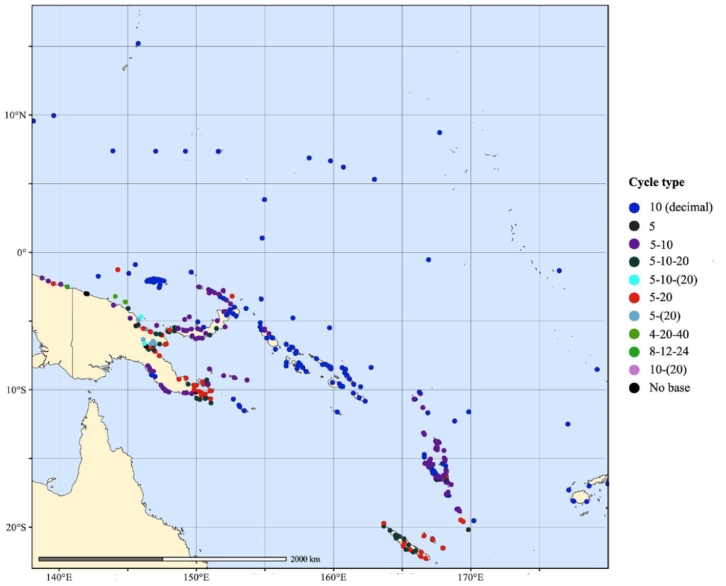

**Map 15.1:** Distribution of numeral cycles in the SW Pacific

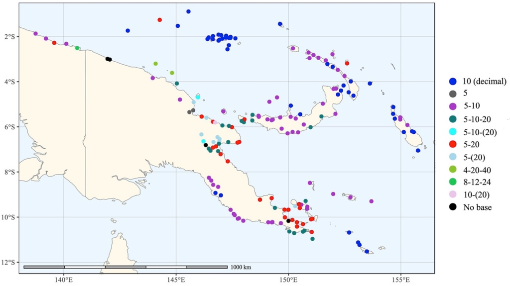

**Map 15.2:** Distribution of numeral cycles in NW Melanesia

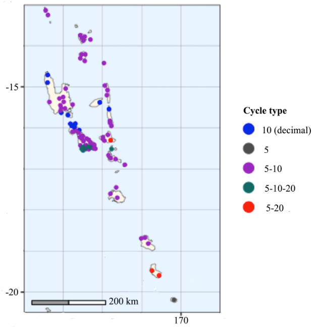

**Map 15.3:** Distribution of numeral cycles in Vanuatu

Languages with a base-5-20 system are found scattered among NNG and PT languages of mainland New Guinea, in a clump in southern New Caledonia and the Loyalties, and in various isolated spots: one language each on Ninigo Atoll (Seimat, Adm), Lihir (MM, east of New Ireland) and on Ambrym (NCV), and in the languages of Tanna (SV).

## 7. The origins of base-5+ systems

It is obvious that most base-5+ systems are hybrids, in the sense that a 5- and a 20-base reflect digit-tallying, while the numeral morphemes of which they are composed reflect those of the POc decimal system.

The POc simple numerals that might survive into a base-5-20 system are, of course, 1–5. Except for 20, other base-5-20 numerals are complex and usually contain one or more simple numerals (e.g. Mangap *lama-ta mi ru* [5-1 and 2] ‘7’). The term for 20 is usually ‘a person’, and this is often of POc ancestry.

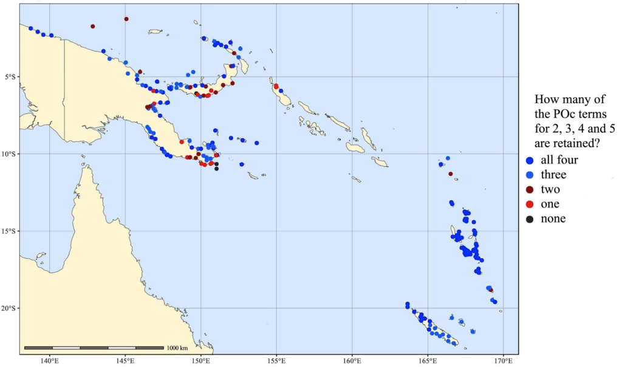

One might expect that base-5-20 systems, being closer to tallying, would have significantly fewer POc numerals than are in base-10 and other base-5+ systems, but the only remotely salient difference in Table 15.8 between retentions in base-5-20 languages and those in other base-5+ languages is that only 29.5 per cent of base-5-20 languages retain all four POc numerals, as against 65.7 per cent in other base-5+ languages. But this difference is compensated for by the fact that 54.5 per cent of base-5-20 languages retain three POc numerals, as against 17.4 per cent in other base-5+ languages. This does not seem to tell us anything significant about base-5-20 retentions in comparison with other base-5+ languages.

**Table 15.8** Retentions of POc numerals from 2 to 5 in each base-5+ system, where n is the number of languages

|  | base-5-20 |  | base-5-10-20 |  | base-5-10 |  | Totals |  |
| --- | --- | --- | --- | --- | --- | --- | --- | --- |
|  | *n* | per cent | *n* | % | *n* | % | *n* | % |
| 0 retentions | 1 | 2.3 | 1 | 2.2 | 1 | 0.7 | 3 | 1.4 |
| one retention | 3 | 6.8 | 5 | 11.1 | 7 | 5.2 | 15 | 6.8 |
| two retentions | 3 | 6.9 | 4 | 8.9 | 12 | 9.0 | 19 | 8.6 |
| three retentions | 24 | 54.5 | 10 | 22.2 | 21 | 15.8 | 55 | 24.8 |
| four retentions | 13 | 29.5 | 25 | 55.6 | 92 | 69.2 | 130 | 58.6 |
| *Totals* | 44 | 100.0 | 45 | 100.0 | 133 | 99.9 | 222 | 100.2 |

The reason for this is probably that base-5-10-20 and base-5-10 languages have each arisen by more than one route. In Vanuatu and New Caledonia these are partly homegrown, away from contact with Papuan languages. We turn now to the genesis of the three base-5+ systems.

### 7.1. Are base-5-20 systems hybrids?

In base-5-20 systems the term for 5 is (or is derived from) a term for ‘hand, arm’ (vol.5:160–162), the term for 10 is often ‘two hands’, the term for 15 sometimes includes the term for ‘foot, leg’ (vol.5:167–168), and the term for 20 is typically ‘man’ or ‘person’ in the sense that one had exhausted one person’s digits (§15.5). It is self-evident that these systems, like Mangap (§15.4.2), are derived from a digit-tally system like those described in §15.2.

Language contact studies suggest strongly that where a language draws at least its basic lexicon from one source and its grammatical structures (at least in part) from another, this is the result of bilingualism—of children growing up with two languages and adapting the structures of their heritage language to those of their ‘other’ language. In a pre-modern context the heritage language is the language of group identity, and that identity is represented by the heritage lexicon (Ross 2013 and references therein). The ‘other’ language may be the language of in-marrying parents or a major language of communication with neighbouring groups.

Base-5-20 numeral systems appear to reflect this pattern fairly directly. In many of them three or all of 2 to 5 reflect the POc forms reconstructed in Table 14.1, and many of them also appear to reflect a POc term for ‘one’.[^11] That is, the lexicon is drawn from speakers’ heritage language. Their 5- and 20-base structure, on the other hand, reflects their ‘other’ language, being a digit-tally system like those found in Papuan languages in various areas of New Guinea (Owens & Lean 2018:76–77). In this sense, then, base-5-20 systems are hybrids.

Owens & Lean (2018:79) provide a map of base-5+ systems in Papuan languages: base-5-20 systems are common, but base-5-10+ systems (i.e. base-5-10-20 and base-5-10) are very rare. Base-5-10+ Oceanic systems are likely, then, to be at least partly “homegrown”, as the next section shows.

### 7.2. The genesis of base-5-10-20 and base-5-10 systems

Map 15.5 shows the sources of terms for 10 in base-5-10+ languages. The numbers underlying the map are shown in Table 15.9.[^12] Terms for 10 that reflect POc *sapuluq or *saŋapuluq ‘10’ (§14.4.5.1) are abbreviated here as *puluq. Terms that reflect *rua-lima [two hand] ‘10’ are shown separately as they tell another story (see below). Other terms that mean ‘two hands’ are also shown, as are terms for 10 with an unknown origin, which make up 35 per cent of the relevant data.

Terms for 10 are singled out here as they provide clues to the history of base-5-10+ systems. Terms for 20 are less informative, as in 31 out of 43 base-5-10-20 languages (72 per cent) the term means ‘person’, and in a further three it means ‘hands and feet’, clearly witnessing to the digit-tally origin of these systems (§15.4.3).

However, there is more than one way in which the role of digit tallying might have been played out.

**Table 15.9** Sources of terms for 10 in base-5-10-20 and base-5-10 languages

|  | base 5-10-20 | % | base 5-10 | % | Totals base-5-10+ | % |
| --- | --- | --- | --- | --- | --- | --- |
| *puluq | 15 | 31.3 | 67 | 59.3 | 82 | 50.9 |
| *rua-lima | 5 | 10.4 | 9 | 8 | 14 | 8.7 |
| ’two hands’¹ | 8 | 16.7 | 0 | 0 | 8 | 5 |
| origin unknown | 20 | 41.7 | 37 | 32.7 | 57 | 35.4 |
| all | 48 | 100.1 | 113 | 100 | 161 | 100 |

¹but not *rua-lima.

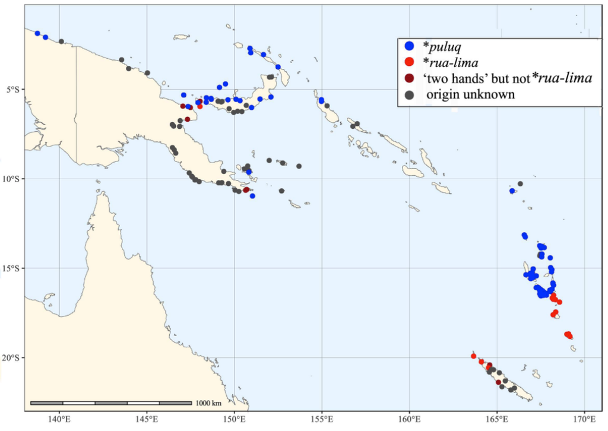

**Map 15.5:** Origins of terms for 10 in base-5-10 and base-5-10-20 systems

4. Possible origins of a base-5-10-20 system
   1. In the production of a hybrid with POc simple numerals and a digit-tallying model, there was a compromise such that the POc numeral for 10 and the 10-cycle from 10 to 19 was never lost.
   2. Under the influence of a decimal system, a numeral for 10 was introduced into an existing base-5-20 system.
   3. Under the influence of a decimal system, the numeral for 3×5 = 15 was lost from an existing base-5-20 system, so that counting from 10 to 19 formed a 10-cycle and the existing numeral for 2×5 was reinterpreted as a 10-base.

There is no obvious way of distinguishing between (4a) and (4b), as outcomes of either process are likely to have a term reflecting *puluq. What can be said is that instances of *puluq did not arise via a (4c) process, to which we now turn.

The *rua-lima area embraces Paama, Epi, Efate and Erromango in Vanuatu and the north of New Caledonia. The northernmost *rua-lima language is thus Paamese (Table 15.10). Immediately to the north of Paama is SE Ambrym (Parker 1970:ix), the only base-5-20 NCV language in the database. None of the *rua-lima languages has a base-5-20 system, but there is good evidence that they are descended from a system like that in SE Ambrym. Three closely related languages in the far north of New Caledonia—Belep, Nyelâyu and Nêlêmwa—illustrate the first step in their development. The Nêlêmwa system is shown in Table 15.10. Belep and Nyelâyu have similar systems, but Belep differs from other other two in one significant feature.

The relevant data are in (5).

|  | Belep | Nyelâyu | Nêlêmwa | Proto Far N NCal | Earlier Oceanic |
| --- | --- | --- | --- | --- | --- |
| ‘10’ | *tũnik* | *-rulī̃k* | *tujic* | *rũnik | *rua-lima |
| ‘2’ | *tu* | *-ru* | *-ru* | *-ru | *rua |
| ‘15’ | *cĩnik* | — | — | *tĩnik | *tolu-lima |
| ‘3’ | *cen* | — | — | *ten | *tolu |
| ‘5’ | *-nem* | *-nem* | *-nem* | *nem | *lima |

Belep arguably has a base-5-20 system (McCracken 2012), Nyelâyu and Nêlêmwa base-5-10-20 (Ozanne-Rivierre 1998; Bril 2014). The shared ancestor of the three languages, Proto Far North New Caledonia, had terms for 10 and 15: *rũnik and *tĩnik respectively. Tentatively, these reflect earlier *rua-lima (2×5) and *tolu-lima (3×5), as the forms for 2 and 3 show that the initial consonants do reflect POc *r- and *t-. The morph *-ni* in *rũnik and *tĩnik reflects *lima ‘5’: cf nearby Yuanga *pɔ-ni* [CLF-5] ‘5’ (Bril 2014), Pije/Jawe/Nemi *nim* ‘5’ (Haudricourt & Ozanne-Rivierre 1982). The origin of final *-k of *rũnik ’and *tĩnik is unknown.

Belep is conservative and continues to reflect *tĩnik ‘15’, which Nyelâyu and Nêlêmwa have lost. All three languages count 10+1, 10+2, 10+3, 10+4. Belep then counts 15, 15+1, 15+2, 15+3, 15+4 for 15 to 19, whereas Nyelâyu and Nêlêmwa count 10+5 to 10+9 for 15 to 19.[^13] In other words, Belep counts three rounds of a 5-cycle from 5 to 19, but Nyelâyu and Nêlêmwa count one round of a 5-cycle from 5 to 9, and one round of a 10-cycle from 10 to 19. Nêlêmwa numerals from 1 to 40 are included in Table 15.10. Thus the loss of *tĩnik ‘15’ and the consequent change in the numerals 15–19 turn the Nyelâyu and Nêlêmwa systems into a base-5-10-20 system.

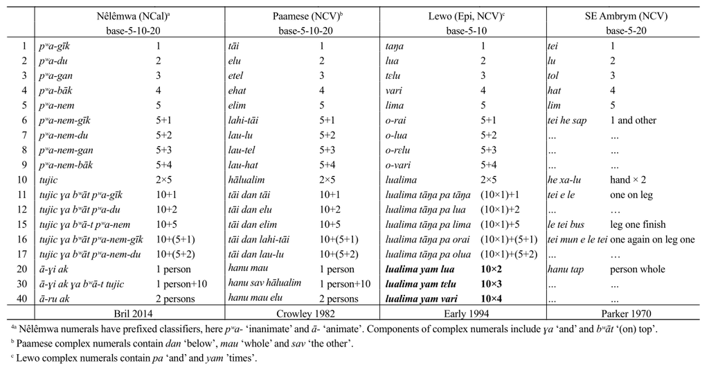

**Figure 15.1:** Nêlêmwa, Paamese, Lewo and SE Ambrym numerals

Returning to the base-5-10 *rua-lima systems on Epi, Efate and Erromango (see Lewo of Epi in Figure 15.1), an obvious inference is that they reflect the same history as the base-5-10-20 systems of New Caledonia (§15.7.1) but have gone a step further. They first underwent the same step as Nyelâyu and Nêlêmwa, replacing a reflex of *tolu-lima [3×5] ‘15’ with an additive 10+5 numeral to give a base-5-10-20 system. Then the *rua-lima systems on Epi, Efate and Erromango also replaced the ‘person’ term for 20 with a 10×2 term, so that the 20-cycle disappeared and the 10-cycle took over (bolded in Table 15.10). Reflexes of *rua-lima were treated as a 10-base: ‘20’ in Epi, for example, is *lualima yam lua* [10×2]. Reflexes of *rua-lima are evidently a single morpheme in speakers’ lexicon, and the result is a base-5-10 system.

The sequence of changes reconstructed here is thus

| base-5-20 | > | replacement of 3×5 by 10+5 | > |  |
| --- | --- | --- | --- | --- |
| base-5-10-20 | > | replacement of ‘person’ by 10×2 | > | base-5-10 |

In this way the *rua-lima systems have acquired a term for 10 without borrowing from a decimal system.

The *rua-lima story has taken us beyond base-5-10-20 systems to base 5-10, but there are also base-5-10 systems in NW Melanesia and north and central Vanuatu that do not share this history. Logically, base-5-10 systems could have originated in two diametrically opposite ways.

7. Possible origins of a base-5-10 system:
   1. from a base-5-10-20 system: the term for 20 (often ‘person’) is lost, giving a base-5-10 system (i.e. as in Epi, Efate and Erromango).
   2. from a decimal system: under the influence of digit tallying simple numerals for 6–9 are replaced with additive numerals 5+1 to 5+4.

If base-5-10 systems were generally descended from base-5-10-20 systems, i.e. via (7a), one would expect the origins of their terms for 10 to pattern similarly to those in base-5-10-20 systems, but Table 15.9 shows that they don’t. A base-5-10 system is twice as likely to display a reflex of *puluq as is a base-5-10-20 system (59.3% vs 31.3%). A smallish proportion of base-5-10-20 systems reflects a term for 10 meaning ‘two hands’: 17 per cent when *rua-lima reflexes are excluded—but no base-5-10 system has such a reflex.

**Table 15.11** Sa and Notsi base-5-10 and base-10 numeral systems

|  | POc | Sa: base-5-10 | Sa: base-10 | Notsi: base-5-10 | Notsi: base-10 |
| --- | --- | --- | --- | --- | --- |
| 1 | (various) | *su* | *wantua* | *a-kuk* | *koso* |
| 2 | *rua | *ru* | *urua* | *a-lua* | *lua* |
| 3 | *tolu | *tıl* | *teul* | *a-tūl* | *tūl* |
| 4 | *pat[i] | *ıt* | *fa* | *a-et* | *et* |
| 5 | *lima | *lim* | *[l,n]ima* | *a-lima* | *lima* |
| 6 | *onom | *le-su ~ li-jia* | *ondo* | *a-pas-kuk* | *wan* |
| 7 | *pitu | *le-ʊru* | *fiti ~ piji* | *a-pas-a-lua* | *it* |
| 8 | *walu | *lı-tıl* | *walo* | *a-pas-a-tūl* | *wān* |
| 9 | *siwa | *li-apat* | *suan* | *a-pas-a-et* | *ciu* |
| 10 | *sa-ŋapuluq | *suŋul* | *tendu* | *saŋaul* | *saŋaul* |

The difference between the forms for 2 to 5 in the two Sa systems leaves open the possibility that one system has been borrowed, but the two Notsi systems may indeed reflect the modification of the more formal base-10 system by everyday tally-based forms for 6–9.

There is, however, a piece of counter-evidence to this hypothesis. Oceanic languages that retain the POc decimal system intact reflect the POc decades *sa[ŋa]puluq ‘1×10’, *rua-ŋapuluq ‘2×10’, *tolu-ŋapuluq ‘3×10’, and so on. But many Oceanic languages retain a reflex of either *saŋapuluq or *ŋapuluq ‘10’ in the sense ‘unit of ten’ (§14.4.5.2), so that multiples of 10 are formed as complex numerals reflecting, e.g. *ŋapuluq rua ‘10×2’, *rua saŋapuluq or *saŋapuluq rua (Table 14.6). If a base-5-10 system were formed from a decimal system just by replacement of 6 to 9, one would expect the POc decade forms to be retained, but this happens only in three closely related languages: Motu, Gabadi and Lala of the Central Papuan subgroup of PT. All other base-5-10 systems, if they retain a reflex of *saŋapuluq or *ŋapuluq ‘10’, treat it as a ‘unit of ten’ morpheme. The inference to be made here is that among base-5-10 systems only those of the three Central Papuan languages can be said with any certainty to be direct descendants of the decimal systems.[^14] All others have undergone other modifications in the process of becoming base-5-10 systems, with ramifications too complex to unravel. The genesis of base-5-10 systems is therefore clouded with some uncertainty.

**Table 15.12** Two MM and two NCV languages reflecting the ligature *lapi-

|  | Early Oceanic | Tungak (MM) N New Ireland | Vinitiri (MM) E New Britain | Maskelynes (NCV) SE Malakula | Lelepa (NCV) Efate |
| --- | --- | --- | --- | --- | --- |
| 1 | *sikai, *tikai | *sikei* | *tikai* | *sua* | *skei* |
| 2 | *-rua | *po-ŋuə* | *u-ruə* | *ɛ-ru* | *rua* |
| 3 | *-tolu | *po-tol* | *u-tulu* | *i-tör* | *tolu* |
| 4 | *-pat[i] | *pu-at* | *i-vati* | *i-vat* | *pati* |
| 5 | *-lima | *palpallima* | *i-limə* | *ɛ-ɾım* | *lima* |
| 6 | *lap-t… | [*lima*]*le*-*sikei* | *ləp*-*tikai* | *mə*-*lɛf*-*tes* | *la*-*tsa* |
| 7 | *lavi-rua | [*lima*]*le*-*ŋuə* | *ləva*-*uruə* | *mə*-*lɛv*-*rʊ* | *la*-*rua* |
| 8 | *lavi-tolu | [*lima*]*le*-*tul* | *ləvu*-*tulu* | *mə*-*lɛv*-*töɾ* | *la*-*tolu* |
| 9 | *lavi-pat[i] | [*lima*]*le*-*at* | *ləvu*-*vati* | *mə*-*la*-*pat* | *l*-*for* |
|  |  | Fast 1990 | van der Mark 2007 | Healey 2013 | Lacrampe 2014 |

### 7.3. Numerals 6–9 and numeral ligatures in base-5-10 languages

In base 5-10 languages each of the numerals 6–9 typically consists of the numeral for 5 followed by one of the numerals 1–4 or variants thereof. In some languages the numerals 1-4 directly follow the 5 numeral, in others a conjunction or a ligature intervenes. A ligature is a morpheme, often derived from a verb, that has no other function in the language; in particular, it is not a conjunction. In constructions with a conjunction or a ligature, 5 may be omitted, leaving the conjunction/ligature plus a numeral between 1–4. This happens in all the languages in Table 15.12. For example, in Tungak, 7 is either *lima-le-ŋuə* [5-LIG-2] or the abbreviated form *le-ŋuə*.

A language in which 5 and 1–4 are directly concatenated is Dobu (PT), counting *ʔebʷeu* ‘1’, *ʔerua* ‘2’, *ʔeto* ‘3’, *ata* ‘4’, *nima* ‘5’, *nima ʔebʷeu* ‘6’, *nima ʔerua* ‘7’, *nima ʔeto* ‘8’, *nima ata* ‘9’, *sanau* ‘10’.

A language that makes transparent use of a conjunction is Tuam (NNG), counting *es* ‘1’, *ru* ‘2’, *tol* ‘3’, *paŋe* ‘4’, *lim* ‘5’, *lim be es* ‘6’, *lim be ru* ‘7’, *lim be tol* ‘8’, *lim be paŋ* ‘9’, *saŋul* ‘10’.

For NCV languages Lynch (2009) reconstructs three ligatures: PNCV *lave-a, S Santo/N Malakula *[la]kau-, C and S Malakula *zau-. PNCV *lave-a has widespread reflexes in Vanuatu: in the languages of the Torres and Banks Islands, Maewo, Pentecost (except Raga), the Shepherds and Efate, and in some Ambrym languages, in all base-5-10 Santo languages and some base-5-10 Malakula languages, and in Paamese (base-5-10-20). PNCV *lave-a also has cognates in three MM languages, as Lynch recognises: Tungak, Vinitiri and Tolai (the Tolai reflexes closely resemble those in Vinitiri). It evidently reflects POc *lapi ‘take, get, give’ (vol.5:426).

**Table 15.13** New Britain languages and Äiwoo of the Reefs reflecting the ligature *polo-

|  | Early Oceanic | Vitu (MM) French Islands | Bola (MM) New Britain | Avau (NNG) New Britain | Äiwoo (TM) Reef Islands |
| --- | --- | --- | --- | --- | --- |
| 1 | *sikai, *tikai | *katiu* | *taku* | *ke* | *ñi-gi* |
| 2 | *-rua | *rua* | *rua* | *su* | *li-lu* |
| 3 | *-tolu | *tolu* | *tolu* | *moyok* | *eve* |
| 4 | *-pat | *vata* | *va* | *pɛnɛl* | *u-væ* |
| 5 | *-lima | *lima* | *lima* | *limi* | *vi-li* |
| 6 | *lap-tikai | *polo* *katiu* | **polo**tara | *ke* *polo* | *pole*-*gi* |
| 7 | *lavi-rua | *polo* *rua* | __*polo*_rua_ | *su* *polo* | *pole*-*lu* |
| 8 | *lavi-tolu | *polo* *tolu* | __*polo*_tolu_ | *moyok* *polo* | *pole*-*e* |
| 9 | *lavi-pat | *polo* *vata* | __*polo*_va_ | *pɛnɛl* *polo* | *polo*-*uvæ* |
|  |  | van den Berg & Bachet 2006 | van den Berg & Wiebe 2019 | author’s fieldnotes | Næss 2016 |

One other ligature appears to transcend local boundaries. This is *polo-*, glossed as Vitu ‘go aboard’ (van den Berg & Bachet 2006) and Bola ‘go across’ (Wiebe n.d.). It appears to occur in Bali, Vitu, Bola, Avau and Äiwoo—“appears” because one cannot be certain whether the ligatures in these languages are cognate or merely homophonous. The data are in Table 15.13.

## 8. Pulling the threads together

### 8.1. Did POc speakers have a base-5-20 system?

The hybridisation referred to in §15.7 implies that both decimal and tally-based systems were in simultaneous use in some locations. Was this already the case in POc?

This inference is partially supported by the distribution of base-5-20 systems in Map 15.1, as they are found dotted across New Guinea with a couple of examples in the Bismarcks.

Further evidence comes from non-Oceanic Austronesian languages immediately to the west. Austronesian languages around Cenderawasih Bay (just east of the Bird’s Head of New Guinea) are members of the South Halmahera/West New Guinea (SHWNG) subgroup. They also use ‘person’ for 20 (Schapper & Hammarström 2013:432–433) within a base-5-10-20 system (Ongkodharma n.d.; Dalrymple & Mofu 2012). Thus speakers of SHWNG and Oceanic languages that neighbour Papuan-speaking groups have in a number of cases acquired a tally system. On the other hand, numeral systems of SHWNG and Oceanic languages that do not immediately neighbour Papuan-speaking groups show no evidence of a tally system. The SHWNG languages of Halmahera and Ambel in the Rajah Ampat islands have a straightforward decimal system inherited from PMP (Maan 1951; Bowden 2001; Arnold 2018), and Map 15.1 shows that Oceanic languages distant from New Guinea have decimal systems. The likelihood that tally systems in Austronesian languages arose through copying rather than inheritance is also evidenced by the fact that their distribution within Papuan-speaking areas is rather random. Dusner of Cenderawasih Bay has a base-5-10-20 system with ‘person’ for 20 (Dalrymple & Mofu 2012), whilst its close relatives Biak and Wooi reflect a decimal system inherited from PMP (Van den Heuvel 2006; Sawaki 2016).

The mechanism of copying, namely childhood bilingualism, was briefly described in §15.7.1, but the question of the languages in which children grew up bilingually was left open. Were they bilingual because their parents spoke different languages or because everyone in the community spoke a lingua franca alongside their heritage language?

There is no linguistic evidence to support an answer, but the simplest account is that after speakers of pre-Oceanic arrived in the Bismarcks, there were soon marriages with Papuan speakers. If Hage & Marck (2003) are right that POc society was matrilocal, then adult males joined POc-speaking hamlets,[^15] and, as adult language learners are wont to do, imposed their own ways of speaking on the language of their new community. Their children either inherited these ways of speaking or, more probably, grew up bilingually, restructuring their Austronesian language on the model of the Papuan language(s) of their fathers (§15.7.1). One of these ways of speaking was a digit-tallying strategy. The inference that the decimal system and digit-tallying were used side by side is unproblematic and so is the inference that this resulted in hybrid systems (§15.7.1).

The discussion above answers some of the questions asked in the introduction to this chapter. Base-5+ systems are found in much of NW Melanesia because of contact with Papuan speakers who used such systems. They are absent from much of Oceanic because Oceanic speakers were the earliest inhabitants of Remote Oceania.

### 8.2. The Southern Oceanic question

The paragraph above leaves an important fact unaccounted for, namely the Southern Oceanic digit-tally area covering much of Vanuatu and all of the Loyalty Islands and New Caledonia. In this area there is no evidence of human habitation before Oceanic speakers arrived. How did base-5+ systems come to be here? This is the Southern Oceanic question. Any answer to it must also account for the fact that the distribution of system types differs between Vanuatu and New Caledonia (Map 15.1).

Blust (2005:552–553) asks a variant of the Southern Oceanic question. He queries the historical reasons for the distribution of “quinary” systems, in which he includes any base-5+ system. He links the distribution of quinary systems to the distributions of other features, one linguistic, one biological, and two cultural. The last are not relevant here. The linguistic feature is the distribution of serial verb constructions. The biological feature is the unexpected phenotype of Oceanic speakers across Melanesia, whose people (Blust 2005:554)

> are almost invariably characterized by darker skins and frizzier hair than other An [Austronesian] speakers, and in this respect are largely indistinguishable from most Papuan speakers. In some parts of Melanesia beyond the reach of Papuan languages, as in the islands of Espiritu Santo and Malakula in Vanuatu, the prominent noses and full beards of many men are strikingly similar to features common among New Guinea highlanders.

This is problematic because Blust (2005:555) assumes “on distributional grounds that POc speakers were southern Mongoloids” and

> if (all) An speakers had acquired Papuan physical, cultural, and linguistic traits through contact in western Melanesia, these would have been part of the linguistic communities ancestral to those of Vanuatu, southern Melanesia, Micronesia, and Polynesia. But this is not true, because Papuan phenotypic, cultural, and linguistic traits are essentially absent in Micronesia and Polynesia.

On the basis of these observations Blust argues that speakers of Papuan languages must have already been present in Vanuatu long before the arrival of Oceanic speakers. He recognises that there is no archaeological evidence for this, but finds the linguistic evidence compelling.[^16] He rightly comments (2005:553) that the presence of ‘one man’ for 20 in Paamese (NCV) and in NCal languages invites a Papuan-based explanation.

Pawley (2006:243–248) offers a response to Blust. He proposes that Oceanic speaking migrants from the Bismarcks were not necessarily all of one phenotype. Some might have been “southern Mongoloid”, others “Papuan”. The people who “reached Tonga, presumably via Vanuatu and Fiji” were of the former phenotype (2006:248). The linguistic evidence, Pawley suggests, is in any case not compelling. Serial verb constructions are reconstructable to POc (one kind is reconstructed in vol.2:256–282), and not an outcome of Papuan contact. He surmises that “quinary” numeral systems may have existed in early Oceanic alongside decimal systems (cf §15.2) or that they may have spread into Southern Oceanic languages after initial Lapita settlement.

Blust (2005) and Pawley (2006) were followed by Donohue & Denham (2008), who added several phonological features to Blust’s list. Blust wrote an “addendum” to their paper in which he seemingly modified his conclusion of three years earlier and wrote (2008:455):

> Putting aside the current lack of archaeological support, the idea that large numbers of Papuan speakers who had adopted key elements of Proto-Oceanic culture arrived in Vanuatu shortly after the first wave of SM [southern Melanesian] Austronesians is not inherently implausible.

Posth et al. (2018) comment that

> The almost complete replacement of a population’s genetic ancestry that leaves the original languages in situ is extremely rare—possibly without precedent—in human history and requires explanation.

As far as one can tell, the misalignment they see between genetic replacement and linguistic continuity has its linguistic roots in Blust’s (2005, 2008) and Donohue & Denham’s (2008) papers. But there is an alternative explanation which avoids the misalignment and was hinted at by both Pawley (2006) and Blust (2008). There was apparently quite intense contact between Papuan speakers and pre-Oceanic speakers soon after the latter’s arrival in the Bismarcks, with Papuan speakers marrying into pre-Oceanic speaking villages and influencing the way people counted (and perhaps modifying the linguistic inventory in other ways) (§15.8.1). If this is true, it is a reasonable inference that the base-20 and base-5-20 systems found in Vanuatu have their ancestry in the Bismarcks. In other words, the ‘Papuans’ who arrived in southern Oceania perhaps 300 years after the first Lapita arrivals spoke one or more Oceanic languages. Murray Cox, in his contribution to Bedford et al. (2018) (a set of commentaries on Skoglund et al. 2016, Posth et al. 2018 and Lipson et al. 2018), arrives independently at a similar conclusion, echoing Pawley (2006), and suggests that Papuan speaking communities in the Bismarcks may also have shifted to Oceanic languages as part of their absorption into Lapita culture. Sometime after their transition to Lapita and Oceanic, some of their number migrated to (perhaps various islands in) Vanuatu.[^17]

By implication the account above touches on two Oceanic-speaking groups outside Vanuatu. One is the Reefs and Santa Cruz Islands, where modern but not ancient genetic material is available. Åshild Næss, in her contribution to Bedford et al. (2018), suggests that a hypothesis of two migrations to the Reefs and Santa Cruz is linguistically plausible, as the Äiwoo language of the Reefs, at least, appears structurally conservative and the archaeological evidence indicates that Lapita settlement occurred early, yet the genetic evidence points strongly to ‘Papuan’ immigration. The presence of base-5-10 numeral systems in Äiwoo and in Natügu of Santa Cruz places them typologically with Vanuatu, not the Solomons.

The second group comprises speakers of the languages of the Loyalties and New Caledonia, which form a single subgroup within SOc. Because ancient and modern genetic material has been available from Vanuatu but not from New Caledonia, the hypothesis that ‘Papuan’ migrants southward were Oceanic speaking has focussed on Vanuatu. Might it also apply to New Caledonia? Early in this section a typological difference in numeral systems between Vanuatu and New Caledonia was noted. In Vanuatu we find a few decimal systems, numerous base-5-10 systems, a cluster of base-5-10-20 systems and very few base-5-20 systems (Map 15.1). In New Caledonia, on the other hand, there are no decimal or base-5-10 systems, but base-5-20 systems in the Loyalties, in the northernmost NCal languages and in the southern half of the mainland, and base-5-10-20 systems in the rest of the mainland.

Base-5-10 systems elsewhere in Vanuatu do not reflect this history, nor do the base-5-10-20 systems clustered in south Malakula. That the latter arose in situ through the modification of base-10 systems cannot be excluded, but the possibility that the base-5-10-20 arose through in-situ hybridisation can be excluded, as it requires the immediate presence of Papuan speakers. A plausible alternative explanation is that the clusters of base-10 and base-5-10-20 systems are the results of bottlenecks during the later immigration, i.e. one group brought a base-10 system with them and settled in north Malakula, another group a base-5-10-20 system and occupied a location in southwest Malakula. This is a matter for more research.

## 9. Conclusion

This chapter complements Chapter 14. The latter reconstructs, along with numeral classifiers, the POc decimal numeral system. The present chapter tracks the history of base-5-20, base-5-10-20 and base-5-10 systems. These three numeral systems all reflect in some measure the influence of digit tallying which was evidently present in many early Oceanic communities in NW Melanesia, presumably as the result of bilingualism in a Papuan language. Two digit tally areas are found, one in NW Melanesia, the other in Vanuatu and New Caledonia. There is no evidence that POc speakers used a tally-based base-5-20 system, and it is very probable that such systems developed early alongside the inherited decimal system, and that the two systems coexisted in some communities because they had different functions.

Recent genetic research indicates that relatively large numbers of Papuan speakers arrived in Vanuatu, and probably in the Loyalties and New Caledonia, over a period that began only a few centuries after the original Oceanic settlers of the Lapita culture, and that these Papuan speakers are responsible for the base-5+ numeral systems found in SOc languages. This chapter puts forward the hypothesis that these “Papuans” had already shifted to Oceanic languages before they moved from NW Melanesia to the SOc area and simply brought NW Melanesian base-5+ counting with them. This does not preclude further developments in these systems after their speakers’ arrival, and one such set of developments, in languages that reflect *rua-lima for ‘10’, is sketched in §15.7.2.

Finally, the previous section suggests that their numeral systems are at least consistent with hypotheses that the Reefs Islands, Santa Cruz, the Loyalty Islands and New Caledonia were also recipients of “Papuan” immigration after the original arrival of speakers of an Oceanic lect or lects. The linguistic evidence from numeral systems suggests that immigration into the Loyalty Islands and New Caledonia was via central Vanuatu.

## Notes

[^1]: Whether one calls complex (phrasal) numerals like English *one hundred and seventy three* lexical items depends on one’s theory of grammar, a matter that is beyond the scope of this discussion.
[^2]: With minor differences, this is the position taken by Lynch (2009:401–403), who did not have access to cognates outside Vanuatu.
[^3]: The form for 9, *meper* is rather opaque, but von Prince (2012:401) cites nearby Dalkalaen *melafer* and Daakie *melapet*, which still reflect the ligature without the abbreviation that occurs in Daakaka.
[^4]: Codrington (1885:223–228) coined the term “imperfect decimal” for base-5-10. Lynch extends it to include subtractive numerals between 6 and 9 (Garde 2015:124). Blust’s (2013:280) “structurally modified decimal” adds to this by including any arithmetical operation used to generate a numeral between 6 and 9.
[^5]: A minuend is the number from which another number is subtracted.
[^6]: Haplology is the loss of one of two successive (near-)identical syllables.
[^7]: Just as in a decimal system the next base is 10 × 10 = 100, so in a binary system the next base is also BASE × BASE, i.e. 2 × 2 = 4.
[^8]: The terms in this table are drawn from Waters (1996), but corrected from Waters (1998). The morpheme-by-morpheme glosses are mine, based on Waters’ notes.
[^9]: ‘NW Melanesia’ is a convenient abbreviation for ‘New Guinea and the Bismarck Archipelago plus Bougainville’.
[^10]: “Pre-Oceanic” because the innovations that characterised POc had not yet occurred (Pawley 2008:52).
[^11]: Terms for ‘one’ are omitted from Table 15.8 because of the difficulties associated with their reconstruction (§14.4.1ff).
[^12]: In principle sources of terms for 10 in base-5-10-20 and base-5-10 could be mapped separately, but the distributional differences between them are slight, apart from the fact that there are no base-5-10 systems in New Caledonia (Map 15.1).
[^13]: Thus Nyelâyu *pʷa-rulĩk bʷār pʷar-nem* [CLF-10 top CLF-5] ‘15’.
[^14]: The numeral systems of these three languages are unlike other base-5-10 systems in other respects. The numerals 6-9 are not formed by simple addition. Motu counts *taura-toi* 2×3 = 6, *hitu* 7 (< POc *pitu ‘7’), *taura-hani* 2×4 = 8, *taura-hani ta* (2×4)+1 = 9. The presence of *hitu* ‘7’ implies local modification of a decimal system.
[^15]: Posth et al’s (2018) literature summary gives some support to this scenario. Polynesian populations have maternal ancestry of almost entirely Austronesian origin but paternal ancestry which is more than 60 per cent ‘Papuan’. They cite Kayser et al. (2006), Wollstein et al. (2010), and Skoglund et al. (2016).
[^16]: Blust alludes to the fact that Papuan speakers had allegedly found their way as far as Santa Cruz, located in isolation between the Solomons and Vanuatu island chains. However, Ross & Næss (2007) have shown that the languages of the Reefs Islands and Santa Cruz are Oceanic Austronesian, not, as earlier claimed, Papuan. The easternmost Papuan languages are Savosavo and Lavukaleve in the central Solomons.
[^17]: Lipson et al (2020) summarise and validate the findings mentioned here, but prefer a single large-scale Papuan intrusion rather than repeated intrusions over centuries.